# deSolveで解く定係数二階同次方程式

2022/11/01

## はじめに

- 自発的には揺れないボロビルの力学的振動は，単純化すると以下のように表されます．

\[ \frac{d^2y}{d^2t} + k\frac{dy}{dt} + \omega^2 y = 0 \]

- \(y\)が揺れ幅（変位），\(\omega\)が固有振動数，\(k\)が抵抗，\(t\)は時間を表します．
- これをプロットしてみましょう．

## 閉じた解を求める

- 定係数二階同次方程式なので数学的に解くことができます．細かい計算は省略します．

\[ y = C_1 e^{-\frac{k}{2} t} \cos{ \Bigg ( t \sqrt{ \omega^2 - \frac{k^2}{4}} \Bigg )} + C_2 e^{-\frac{k}{2}t} \sin{ \Bigg ( t \sqrt{ \omega^2 - \frac{k^2}{4}} \Bigg ) } \]

- ほぼこのまま，curve関数で描画できます．

```r
C1 <- 5; C2 <- 5; k <- 0.1; omega <- 1
curve(C1*exp(-k/2*t)*cos(t*sqrt(omega^2-k^2/4))
    + C2*exp(-k/2*t)*sin(t*sqrt(omega^2-k^2/4)),
    0, 100, n=1000, xname=expression(t), ylab=expression(y))
```

## 閉じた階のプロット

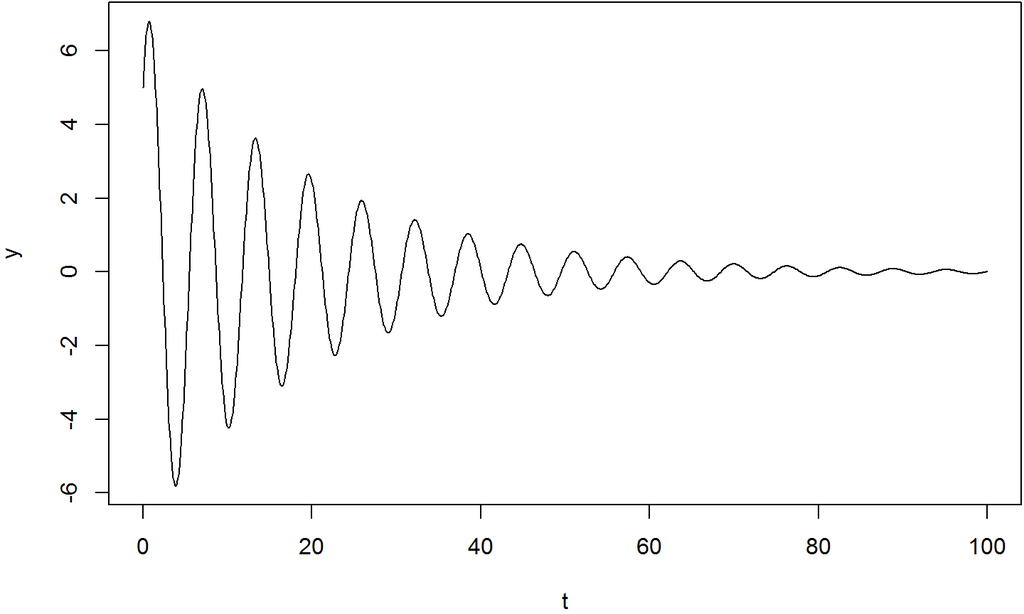

## 微分方程式のまま処理する

- \(y=y_1\)，\(dy_1/dt=y_2\)と置いて，連立微分方程式に展開してみましょう．

\[ \frac{dy_1}{dt} = y_2\ \ \ \frac{dy_2}{dt} = - ky_2 -\omega^2 y_1 \]

- この状態で、deSolveパッケージに渡すことができます。

```r
library("deSolve")
model <- function(t, Y, params){
  with(as.list(params),{
    dy1 = Y[2]; dy2 = -omega^2*Y[1] - k*Y[2]; list(c(dy1, dy2))
  })
}

Y <- c(y1=5, y2=2.371872) # 変位Y1とその微分の初期値
times <- seq(0, 100, 0.1) # t=0からt=100まで0.1刻みで計算する
out1 <- ode(Y, times, model,
    parms = c(omega=1, k=0.1, F0=0.35, beta=1)) # 常微分方程式を計算する
plot(y1 ~ time, data=out1, type="l",
    ylab=expression(y), xlab=expression(t), lwd=1)
```

## deSolveによる常微分方程式のプロット

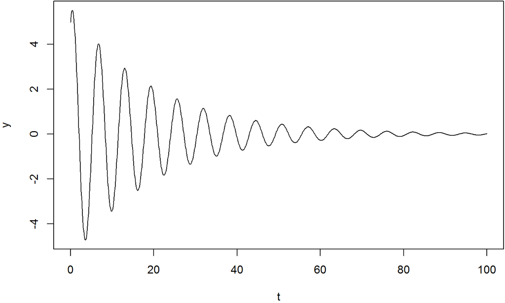

## deSolveパッケージに関して

- 初期値問題，微分代数方程式，偏微分方程式も解ける優れモノです．詳しい説明は以下を参照してください．

[Soetaert, Petzoldt, and Setzer (2010) “Solving Differential Equations in R: Package deSolve,” *Journal of Statistical Software*, Vol.33(9)](https://www.jstatsoft.org/article/view/v033i09)